# Molecular Heatmap - Exact Feature Match

Jordan Lee

2/2/2021

# TMP GDAN working group

## Figure 4 Suggestion

### Question

We see (in other figures) that different teams have similar high classification performance. Is this similar performance due to selection of the same feature sets?

### Rationale

If we see teams picking different features, this suggests that there are multiple biomarkers that can predict cancer subtype well. An alternative explanation if we see teams picking different features, is that perhaps there is some relationship (correlation, biological pathway connection, etc.) between features so in a sense the teams are picking the “same” features if they are correlated.

In this analysis we will address: are groups picking the same features? What is the relationship?

### Analysis

The preprocessing and generation of these files was conducted in a custom python pipeline. A summary of the pipeline is:

Scaling data - METH, GEXP, and MIR

Non-scaled data - MUTA, CNVR

I want to see the differences between features. Data was scaled - all samples for a given feature have mean 0 and sd 1. then ran through normal pipeline

Note in calculating z-scores, NAs were omitted

```r
# Hardcoded
######
cancer <- 'GEA' # 'GEA', 'LGGGBM', 'BRCA'

outdir ='../data/figure_panel_b/'

file_imp_aklimate <- paste(
  '../src/aklimate_feature_importance_scores_20200807/AKLIMATE_TEMPLATE_FULLY_TRAINED_',
  cancer,
  '_20200423_aklimate_ranked_feature_importance.tsv',
  sep=''
)

yes_scale <- c('N:METH', 'N:GEXP','N:MIR') # which fts to scale


#####
# Packages and Functions
#####
suppressPackageStartupMessages(library(tidyr))
suppressPackageStartupMessages(library(dplyr))
suppressPackageStartupMessages(library(ComplexHeatmap))
suppressPackageStartupMessages(library(stringr))
suppressPackageStartupMessages(library(data.table))
suppressPackageStartupMessages(library(testit))
suppressPackageStartupMessages(library(knitr))
suppressPackageStartupMessages(library(ggplot2))
suppressPackageStartupMessages(library(circlize))
suppressPackageStartupMessages(library(docstring))


model2team <- function(df){
  #' Read team model names and map to team name.
  #' Returns named vector of specific team models.
  #' Names: "JADBIO", "CForest", "AKLIMATE", "SubSCOPE", "SKGrid"
  headers_vector <- c()
  names_vector <- c()
  models <- colnames(df)[!colnames(df) %in% c('featureID', 'Total')]

  for (header in models){
    if (grepl('gnosis', header, fixed=TRUE)){
      headers_vector <- c(headers_vector, header)
      names_vector <- c(names_vector, 'JADBIO')
    }
    else if (grepl('CF', header, fixed=TRUE)){
      headers_vector <- c(headers_vector, header)
      names_vector <- c(names_vector, 'CForest')
    }
    else if (grepl('nn_jg', header, fixed=TRUE)){
      headers_vector <- c(headers_vector, header)
      names_vector <- c(names_vector, 'SubSCOPE')
    }
    else if (grepl('AKLIMATE', header, fixed=TRUE)){
      headers_vector <- c(headers_vector, header)
      names_vector <- c(names_vector, 'AKLIMATE')
    }
    else {
      headers_vector <- c(headers_vector, header)
      names_vector <- c(names_vector, 'SKGrid')
    }
  }
  names(headers_vector) <- names_vector
  return(headers_vector)
}


get_colors <- function(df){
  #' Pull color codes based on total number of subtypes found in "Labels" column
  #' Input df that contains column "Labels" where subtypes are
  #' Returns vector of set heatmap color codes for subtypes
  nsubs <- df %>%
    select(Labels) %>%
    unique() %>%
    nrow() %>%
    as.integer()
  if (nsubs == 4){
    color_codes <- c(
      "1" = 'salmon4',
      "2"='red3',
      "3"='orangered',
      "4"='orange1'
    )
  } else if (nsubs == 7){
    color_codes <- c(
      "1" = '#F58748',
      "2" ='#A95757',
      "3"='#4A2918',
      "4"='red3',
      "5"='orangered',
      "6"= 'salmon',
      "7" = 'orange1'
    )
  }
  return(color_codes)
}



get_base_heatmap <- function(prefix, cancer, header_jadbio, header_cforest, header_aklimate, header_subscope, header_skgrid){
  #' Create base heatmap - no hallmark info. For exploratory purposes
  ######
  # Preprocess
  #####
  # A. Order by subtype
  df_transform <- df %>% arrange(Labels)
  # B. Column annotation
  subtypestring <- paste(cancer, '_', sep='')
  subtype_ha <- rowAnnotation(
    Subtype =
      select(df_transform, Labels) %>%
      mutate_all(funs(str_replace(., subtypestring, ""))) %>%
      as.matrix(),
    na_col = 'grey',
    col = list(
      Subtype = get_colors(df)
    ),
    show_annotation_name = FALSE,
    simple_anno_size = unit(3, "mm") # width
  )
  # C. Select data type
  df_transform <- df_transform %>%
      select(-Labels) %>%
      select(-all_of(cancer)) %>%
      select(starts_with(prefix))
  if (ncol(df_transform) != 0){

    ##### TESTING NEW START ####
    mat <- df_transform %>%
        as.matrix() %>%
        t()
    print(prefix)

    #####
    # 1. Generate temp Heatmap
    # and pull row/col order
    #####
    # Scale if appropriate
    #z-scores == each ft row will have mean 0, sd 1. omit NAs
    if (prefix %in% yes_scale){
      mat <- scale(t(mat), center=TRUE, scale=TRUE)
    } else {
      mat <- t(mat) #flip for heatmap looks
    }
    # Heatmap
    ht_rows <- nrow(mat)
    ht_cols <- ncol(mat)
    fig <- Heatmap(
      mat,
      name = 'first heatmap',
      cluster_rows = FALSE,
      clustering_distance_columns = "euclidean",
      clustering_method_columns = "ward.D",
      cluster_columns = TRUE,
      show_row_names = FALSE,
      show_column_names = FALSE,
      column_title = paste('Features (n=', ht_rows, ')', sep=''),
      row_title = paste('Samples (n=', ht_cols, ')', sep=''),
      right_annotation = subtype_ha
    )
    ####
    # Add team annotation bar
    ####
    # Ordering
    # 1. Get order of features post heatmap clustering
    heatmap_order <- column_order(fig) # index vector
    ftnames_order <- c() # featurename vector
    for (i in heatmap_order){
      add_ft <- colnames(mat)[i]
      ftnames_order <- c(ftnames_order, add_ft)
    }
    # 2. Get new matrix that is ordered by heatmap clustering
    mat2 <- mat[,match(ftnames_order, colnames(mat))]
    #####
    # Build annotation bars of teams feature sets
    #####
    # 1. df of all teams. match ft order in heatmap
    team_df<- df_fts %>%
      filter(featureID %in% ftnames_order) %>%
      arrange(match(featureID, ftnames_order))
    # 2. Pull just the team of interest
    jadbio <- team_df %>%
      pull(header_jadbio) %>%
      as.character()
    cforest <- team_df %>%
      pull(header_cforest) %>%
      as.character()
    aklimate <- team_df %>%
      pull(header_aklimate) %>%
      as.character()
    subscope <- team_df %>%
      pull(header_subscope) %>%
      as.character()
    skgrid <- team_df %>%
      pull(header_skgrid) %>%
      as.character()
    team_list <- HeatmapAnnotation(
      JADBio = jadbio,
      CloudForest = cforest,
      AKLIMATE = aklimate,
      SubSCOPE = subscope,
      SciKitGrid = skgrid,
      col = list(
        JADBio = c('0' = "#333333", '1' = "#D55B5B"),
        CloudForest = c('0' = "#333333", '1' = "mediumpurple1"),
        AKLIMATE = c('0' = "#333333", '1' = "cadetblue1"),
        SubSCOPE = c('0' = "#333333", '1' = "palegreen2"),
        SciKitGrid = c('0' = "#333333", '1' = "#EFA9A9")
      ),
      show_legend = FALSE,
      nTeams= anno_barplot (
        team_df$Total,
        bar_width=1
      )
      # simple_anno_size = unit(2, 'mm') # height
    )
    #####
    # 3. Output Heatmap
    #####
    # Set up saving fig packet
    tiff(
      paste(
        cancer,
        '_ht_base_',
        unlist(strsplit(prefix, ':'))[2],
        '.tiff',
        sep=''
      ),
      width = 1400,
      height = 1200,
      res = 200,
      compression = "none"
    )
    # Draw
    # handle if only 1 feature in heatmap
    if (length(ftnames_order)==1){
      # Sanity check
      ht_rows <- nrow(mat2)
      ht_cols <- ncol(mat2)
      assert('Assertion Error: in if loop for 1 ft but mat2 object dim() does not match',
             is.null(ht_rows) && is.null(ht_cols)
      )

      # If only one feature set ht_rows/cols manually
      ht_rows <- length(mat2)
      ht_cols <- 1

      fig <- Heatmap(
        mat2,
        name = prefix,
        # width = unit(12, 'cm'),
        # height = unit(12, 'cm'),
        cluster_rows = FALSE,
        clustering_distance_columns = "euclidean",
        clustering_method_columns = "ward.D",
        # column_order = ftnames_order, # NO ORDERING NEEDED
        show_row_names = FALSE,
        show_column_names = FALSE,
        column_title = paste('Features (n=', ht_cols, ')', sep=''),
        row_title = paste('Samples (n=', ht_rows, ')', sep=''),
        right_annotation = subtype_ha,
        bottom_annotation = team_list,
        na_col = 'white'
      )
      draw(fig)
      dev.off()
    } else {
      ht_rows <- nrow(mat2)
      ht_cols <- ncol(mat2)
      fig <- Heatmap(
        mat2,
        name = prefix,
        # width = unit(12, 'cm'),
        # height = unit(12, 'cm'),
        cluster_rows = FALSE,
        clustering_distance_columns = "euclidean",
        clustering_method_columns = "ward.D",
        column_order = ftnames_order,
        show_row_names = FALSE,
        show_column_names = FALSE,
        column_title = paste('Features (n=', ht_cols, ')', sep=''),
        row_title = paste('Samples (n=', ht_rows, ')', sep=''),
        right_annotation = subtype_ha,
        bottom_annotation = team_list,
        na_col = 'white'
      )
      draw(fig)
      dev.off()
    }
    print(
      paste(
        'Distance metric = ',
        fig@column_dend_param$distance,
        '. Method = ',
        fig@column_dend_param$method,
        sep=' '
      )
    )
    # Assign to 'output' variables
    return(
      list(
        'results_matrix' = mat2,
        'results_ft_order' = ftnames_order,
        'subtype_annotation' = subtype_ha
      )
    )
  } else {
    return(
      list(
        'results_matrix' = NULL,
        'results_ft_order' = NULL,
        'subtype_annotation' = NULL
      )
    )
  }
}


build_hallmark_vect <- function(hallmark, ftnames_order, platform_of_interest){
  #' Create hallmark vector
  #' for builidng hallmark heatmap
  fts_checked <- c() # sanity check
  hallmark_present <- c()
  for (feature in ftnames_order){
    # 1. Preprocess - to gene symbol
    if (platform_of_interest == 'N:GEXP'){
      GENE <- unlist(strsplit(feature, '::'))[2]
      GENE <- unlist(strsplit(GENE, ':'))[1]
    } else if (platform_of_interest == 'N:METH'){
      GENE <- unlist(strsplit(feature, ':'))[4]
    }
    # 2. Hallmark Mapping
    halls <- mappings[mappings$human_gene_symbol==GENE,]$gs_name %>%
      as.vector()
    # If hallmark present
    if (hallmark %in% halls){
      i <- match(hallmark, halls)
      hallmark_present <- c(hallmark_present, 1)
      fts_checked <- c(fts_checked, feature)
    }
    else {
      hallmark_present <- c(hallmark_present, 0)
      fts_checked <- c(fts_checked, feature)
    }
  }
  return(hallmark_present)
}


mm_normal <- function(x) {
  #' Calculate min-max normalization of input values
  return ((x - min(x)) / (max(x) - min(x)))
}
```

```r
####
# Read in files
####
# A. base files
df <- fread(
  paste(
    '../data/figure_panel_b/',
    cancer,
    '_fts_by_VALUE.tsv',
    sep=''
  )
) %>% as.data.frame()

df_fts <- fread(
  paste(
    '../data/figure_panel_b/',
    cancer,
    '_fts_by_TEAM.tsv',
    sep=''
  )
)%>% as.data.frame()

mappings <- fread(
  '../data/figure_panel_b/hallmarks.tsv'
) %>% as.data.frame()

# B. Importance Score files
imp_aklimate <- fread(
  file_imp_aklimate
) %>% as.data.frame()

# C. Load Mauro's hallmark ranks for all cancer cohorts
load(file='../src/mauro_files/Hallmark_nes_space_20210212.RData')

####
# Define platform for hallmark heatmap
####
if (cancer == 'BRCA'){
  platform_of_interest <- 'N:GEXP'
} else if (cancer == 'LGGGBM'){
  platform_of_interest <- 'N:METH'
} else if (cancer == 'GEA'){
  platform_of_interest <- 'N:METH'
}

####
# Build list of data types present
####
if (cancer == 'BRCA' | cancer == 'GEA' ){
  platforms <- c('N:METH', 'N:MIR', 'I:CNVR', 'B:MUTA', 'N:GEXP')
} else if (cancer == 'LGGGBM'){
  platforms <- c('N:METH', 'I:CNVR', 'B:MUTA', 'N:GEXP')
}
```

```r
# need to update df, but df is based on df_fts

# Purpose: filter for ft rows that occur in >= 2 teams
#first for df_fts
df_fts <- df_fts[df_fts['Total']>=2,]
rownames(df_fts) <- 1:nrow(df_fts) #reset row index names
cols_to_keep <- df_fts$featureID
cols_to_keep <- c(cancer, 'Labels', cols_to_keep)
#second for df
df <- subset(df, select=cols_to_keep)
```

### Section 1: Heatmaps for each data type

Code and figures for all data types

```r
setwd(outdir)

####
# Create Base Heatmap for ALL DATA TYPES
####
# Get models
models <- model2team(df_fts)
# Set up saving fig packet
for (prefix in platforms){
  # A. Base Heatmap
  results_list <- get_base_heatmap(
    prefix,
    cancer,
    models['JADBIO'],
    models['CForest'],
    models['AKLIMATE'],
    models['SubSCOPE'],
    models['SKGrid']
  )

  # B. If platform for Hallmarks Heatmap then save global variables - input for Section 2
  if (prefix == platform_of_interest){
    print('Using this as main platform of interest:')
    print(prefix)
    mat2 <- results_list[['results_matrix']]
    ftnames_order <- results_list[['results_ft_order']]
    subtype_annotation <- results_list[['subtype_annotation']]
    n_fts <- length(ftnames_order)
  }
}
```

```
## [1] "N:METH"
```

```
## [1] "Distance metric =  euclidean . Method =  ward.D"
## [1] "Using this as main platform of interest:"
## [1] "N:METH"
## [1] "B:MUTA"
```

```
## [1] "Distance metric =  euclidean . Method =  ward.D"
## [1] "N:GEXP"
```

[output not shown]

[output not shown]

```
## [1] "Distance metric =  euclidean . Method =  ward.D"
```

One annotation bar (top hallmarks only, all others are not colored)

```r
setwd(outdir)

######
# Explore Hallmarks
######
# 1. Prep
#look up if in hallmark mappings table
n_hallmarks <- c()
pooled_hallmarks <- c()

if (platform_of_interest == 'N:GEXP'){
  for (feature in ftnames_order){
    # 1. Preprocess - to gene symbol
    GENE <- unlist(strsplit(feature, '::'))[2]
    GENE <- unlist(strsplit(GENE, ':'))[1]
    # 2. Hallmark Mapping
    halls <- mappings[mappings$human_gene_symbol==GENE,]$gs_name %>% as.vector()
    # Multiple Hallmarks
    n_hallmarks <- c(n_hallmarks, length(halls))
    pooled_hallmarks <- c(pooled_hallmarks, halls)
  }
} else if (platform_of_interest == 'N:METH'){
  for (feature in ftnames_order){
    # 1. Preprocess - to gene symbol
    GENE <- unlist(strsplit(feature, ':'))[4]
    # 2. Hallmark Mapping
    halls <- mappings[mappings$human_gene_symbol==GENE,]$gs_name %>% as.vector()
    # Multiple Hallmarks
    n_hallmarks <- c(n_hallmarks, length(halls))
    pooled_hallmarks <- c(pooled_hallmarks, halls)
  }
}

# 2. Plot fig: How many hallmarks is a feature associated with?
tiff(
  paste(
    cancer,
    'hallmark_fts',
    unlist(strsplit(platform_of_interest, ':'))[2],
    '.tiff',
    sep=''
  ),
  width = 1400,
  height = 1200,
  res = 200,
  compression = "none"
)
df2 <- table(n_hallmarks) %>% as.data.frame()
colnames(df2)<- c('nHallmarks', 'Freq')
ggplot(data=df2, aes(x=nHallmarks, y=Freq, fill='blue')) +
  geom_bar(stat='identity') +
  geom_text(aes(label=Freq), vjust=-0.3, size=3.5) +
  ggtitle('Histogram - How many hallmarks is a feature associated with?') +
  theme(legend.position = "none")
dev.off()
```

```r
# 3. Plot fig: What hallmarks are fts most often associated with?
tiff(
  paste(
    cancer,
    'hallmark_hist',
    unlist(strsplit(platform_of_interest, ':'))[2],
    '.tiff',
    sep=''
  ),
  width = 1400,
  height = 1200,
  res = 200,
  compression = "none"
)
df2 <- sort(table(pooled_hallmarks), decreasing=T) %>% as.data.frame()
colnames(df2)<- c('Hallmarks', 'Freq')
ggplot(data=df2, aes(x=Hallmarks, y=Freq, fill='blue')) +
  geom_bar(stat='identity') +
  geom_text(aes(label=Freq), hjust=-0.5, size=1.5) +
  ggtitle('What hallmarks are fts most often associated with') +
  theme(text = element_text(size=6)) +
  theme(legend.position = "none") +
  coord_flip()
dev.off()
```

### Section 3: WIP Heatmap with Hallmarks and Feature Importance (Top 5)

```r
# TODO: rm if using version 2
# # Version 1: Get top data from freq
# hallmark_data <- sort(table(pooled_hallmarks), decreasing=T)
# # Find top hallmarks
# print('Heatmap below will use these hallmarks (order matches with heatmap)')
# top <- hallmark_data[1:5]
# top <- names(top)


# Version 2: Find top hallmarks from Pathway NES score
print('Heatmap below will use these hallmarks (order matches with heatmap) based on pathway NES values')
```

```
## [1] "Heatmap below will use these hallmarks (order matches with heatmap) based on pathway NES values"
```

```r
importance <- Hallmark.nes.space[,cancer]
importance <- sort(importance, decreasing = TRUE)
top_NES <- names(importance[1:5])
```

**NEED TO MANUALLY UPDATE THIS CODE CHUNK**

```r
print('need to manually update this')
```

```
## [1] "need to manually update this"
```

```r
gene_set_size <- function(input_hallmark){
  # subset for hallmark rows
  tab<- mappings[mappings['gs_name']==input_hallmark,]
  # count unique gene symbols
  genes <- unique(unlist(tab['human_gene_symbol']))
  return(length(genes))
}

for (h in top_NES){
  print(h)
  print(gene_set_size(h))
}
```

```
## [1] "E2F_TARGETS"
## [1] 200
## [1] "INTERFERON_ALPHA_RESPONSE"
## [1] 97
## [1] "INTERFERON_GAMMA_RESPONSE"
## [1] 200
## [1] "MYC_TARGETS_V1"
## [1] 200
## [1] "G2M_CHECKPOINT"
## [1] 200
```

```r
# TODO add these as argument input into function
header_jadbio <- models['JADBIO']
header_cforest <- models['CForest']
header_aklimate <- models['AKLIMATE']
header_subscope <- models['SubSCOPE']
header_skgrid <- models['SKGrid']

subtype_ha <- subtype_annotation
```

```r
# Function for pulling feature importance scores
normalize_data <- function(df, team_df){
  ## Purpose: min-max normalization and order features to match heatmap
  ## Input df that contains columns c("features","importance")
  ## Input df of all teams
  ## Return vector of normalized values

  # Min max normalize importance scores
  subset_df <- df[,c('features', 'importance')]
  minmax_vals <- mm_normal(subset_df$importance)
  subset_df <- cbind(subset_df, minmax_vals)


  # Map and order ft importances to pooled ft order
  minmax_norm <- c()
  test_ft_order <- c()
  all_features <- subset_df$features
  for (pooled_ft in team_df$featureID){
    if (pooled_ft %in% all_features){
      mm <- subset_df[subset_df$'features'==pooled_ft,]$minmax_vals
      minmax_norm <- c(minmax_norm, mm)
      test_ft_order <- c(test_ft_order, pooled_ft)
    } else {
      minmax_norm <- c(minmax_norm, 0)
      test_ft_order <- c(test_ft_order, pooled_ft)
    }
  }
  return(minmax_norm)
}
```

```r
setwd(outdir)


# Hallmarks by Pathway NES score
vals_1_NES <- build_hallmark_vect(top_NES[1],ftnames_order, platform_of_interest)
vals_2_NES <- build_hallmark_vect(top_NES[2],ftnames_order, platform_of_interest)
vals_3_NES <- build_hallmark_vect(top_NES[3],ftnames_order, platform_of_interest)
vals_4_NES <- build_hallmark_vect(top_NES[4],ftnames_order, platform_of_interest)
vals_5_NES <- build_hallmark_vect(top_NES[5],ftnames_order, platform_of_interest)

# Build annotation bars of teams feature sets.
# 1A. df of all teams. match ft order in heatmap
team_df<- df_fts %>% filter(featureID %in% ftnames_order) %>% arrange(match(featureID, ftnames_order))


########
# 2. Create MinMax Values where appropriate
# or Pull just the team of interest
########
jadbio <- team_df %>% pull(header_jadbio) %>% as.character()
cforest <- team_df %>% pull(header_cforest) %>% as.character()
aklimate_minmax <- normalize_data(imp_aklimate, team_df)
subscope <- team_df %>% pull(header_subscope) %>% as.character()
skgrid <- team_df %>% pull(header_skgrid) %>% as.character()

# Build annotation
col_annot <- HeatmapAnnotation(
  # Names of Annot Bars
  annotation_label  = gt_render(
    c(
      'AKLIMATE', "SubSCOPE", "CloudForest", "JADBio", "SciKitGrid",
      "nTeams",
      top_NES[1],top_NES[2],top_NES[3],top_NES[4],top_NES[5]
    )
  ),

  # A. ft binary membership
  AKLIMATE = aklimate_minmax,
  SubSCOPE = subscope,
  CloudForest = cforest,
  JADBio = jadbio,
  SciKitGrid = skgrid,

  # B. N teams selected
  nTeams= anno_barplot (
    team_df$Total,
    bar_width=1
  ),

  # C. Version 2: Hallmarks by NES
  hallmark1 = vals_1_NES,
  hallmark2 = vals_2_NES,
  hallmark3 = vals_3_NES,
  hallmark4 = vals_4_NES,
  hallmark5 = vals_5_NES,

  col = list(
    AKLIMATE =  colorRamp2(c(0, 1), c("#333333", "cadetblue1")),
    SubSCOPE =  c('0' = "#333333", '1' = "palegreen2"),
    CloudForest =  c('0' = "#333333", '1' = "mediumpurple1"),
    JADBio = c('0' = "#333333", '1' = "#D55B5B"),
    SciKitGrid =  c('0' = "#333333", '1' = "#EFA9A9"),
    hallmark1 = c('0' = "#333333", '1' = "darkgoldenrod3"),
    hallmark2 = c('0' = "#333333", '1' = "darkgoldenrod3"),
    hallmark3 = c('0' = "#333333", '1' = "darkgoldenrod3"),
    hallmark4 = c('0' = "#333333", '1' = "darkgoldenrod3"),
    hallmark5 = c('0' = "#333333", '1' = "darkgoldenrod3")
  ),
  show_legend = FALSE,
  gap = unit(c(0,0,0,0,1,1,0,0,0,0), 'mm')
)
# Plot
ht_rows <- nrow(mat2)
ht_cols <- ncol(mat2)
fig <- Heatmap(
  mat2, #each col will have mean 0, sd 1
  # width = unit(10, 'cm'),
  # height = unit(10, 'cm'),
  name = unlist(strsplit(platform_of_interest, ':'))[2],
  cluster_rows = FALSE,
  cluster_columns = FALSE,
  show_row_names = FALSE,
  show_column_names = FALSE,
  column_title = paste('Features (n=', ht_cols, ')', sep=''),
  column_title_gp = gpar(fontsize = 12),
  row_title = paste('Samples (n=', ht_rows, ')', sep=''),
  row_title_gp = gpar(fontsize = 12),
  left_annotation = subtype_ha,
  bottom_annotation = col_annot,
  use_raster = TRUE,
  na_col = 'white',
  col = colorRamp2(c(-2, 0, 2), c('blue', 'white', 'red'))
)
```

```
## 'magick' package is suggested to install to give better rasterization.
##
## Set `ht_opt$message = FALSE` to turn off this message.
```

```r
# Set up saving fig packet
tiff(
  paste(
    cancer,
    'ht_ftimportance_top5',
    unlist(strsplit(platform_of_interest, ':'))[2],
    '.tiff',
    sep=''
  ),
  width = 1600,
  height = 1400,
  res = 200,
  compression = "none"
)
draw(fig,heatmap_legend_side = c('left'))
dev.off()
```

```r
setwd(outdir)

# TODO make less janky so autopopulates the annotation names
if (cancer == 'LGGGBM' ){
  # # Version 1: Hallmarks by Freq
  # vals_1 <- build_hallmark_vect(top[1],ftnames_order, platform_of_interest)
  # vals_2 <- build_hallmark_vect(top[2],ftnames_order, platform_of_interest)
  # vals_3 <- build_hallmark_vect(top[3],ftnames_order, platform_of_interest)
  # vals_4 <- build_hallmark_vect(top[4],ftnames_order, platform_of_interest)
  # vals_5 <- build_hallmark_vect(top[5],ftnames_order, platform_of_interest)

  # Version 2: Hallmarks by Pathway NES score
  vals_1_NES <- build_hallmark_vect(top_NES[1],ftnames_order, platform_of_interest)
  vals_2_NES <- build_hallmark_vect(top_NES[2],ftnames_order, platform_of_interest)
  vals_3_NES <- build_hallmark_vect(top_NES[3],ftnames_order, platform_of_interest)
  vals_4_NES <- build_hallmark_vect(top_NES[4],ftnames_order, platform_of_interest)
  vals_5_NES <- build_hallmark_vect(top_NES[5],ftnames_order, platform_of_interest)

  # Build annotation bars of teams feature sets.
  # 1A. df of all teams. match ft order in heatmap
  team_df<- df_fts %>% filter(featureID %in% ftnames_order) %>% arrange(match(featureID, ftnames_order))


  ########
  # 2. Create MinMax Values where appropriate
  # or Pull just the team of interest
  ########
  jadbio <- team_df %>% pull(header_jadbio) %>% as.character()
  cforest <- team_df %>% pull(header_cforest) %>% as.character()
  aklimate_minmax <- normalize_data(imp_aklimate, team_df)
  subscope <- team_df %>% pull(header_subscope) %>% as.character()
  skgrid <- team_df %>% pull(header_skgrid) %>% as.character()

  # Build annotation
  col_annot <- HeatmapAnnotation(
    annotation_label  = gt_render(
      c(
        'AKLIMATE', "SubSCOPE", "CloudForest", "JADBio", "SciKitGrid",
        "nTeams",
        top_NES[1],top_NES[2],top_NES[3],top_NES[4],top_NES[5]
      )
    ),

    # A. ft binary membership
    AKLIMATE = aklimate_minmax,
    SubSCOPE = subscope,
    CloudForest = cforest,
    JADBio = jadbio,
    SciKitGrid = skgrid,

    # B. N teams selected
    nTeams= anno_barplot (
      team_df$Total,
      bar_width=1
    ),

    # TODO need to manually update the name
    # C. Version 1: Hallmarks by freq
    # "APICAL JUNCTION (n=200)" = vals_1,
    # "COMPLEMENT (n=200)"= vals_2,
    # "ESTROGEN RESPONSE LATE (n=200)" = vals_3,
    # "INFLAMMATORY RESPONSE (n=200)" = vals_4,
    # "APOPTOSIS (n=161)" = vals_5,
    # D. Version 2: Hallmarks by NES
    hallmark1 = vals_1_NES,
    hallmark2 = vals_2_NES,
    hallmark3 = vals_3_NES,
    hallmark4 = vals_4_NES,
    hallmark5 = vals_5_NES,

    col = list(
      AKLIMATE =  colorRamp2(c(0, 1), c("#333333", "cadetblue1")),
      SubSCOPE =  c('0' = "#333333", '1' = "palegreen2"),
      CloudForest =  c('0' = "#333333", '1' = "mediumpurple1"),
      JADBio = c('0' = "#333333", '1' = "#D55B5B"),
      SciKitGrid =  c('0' = "#333333", '1' = "#EFA9A9"),
      hallmark1 = c('0' = "#333333", '1' = "darkgoldenrod3"),
      hallmark2 = c('0' = "#333333", '1' = "darkgoldenrod3"),
      hallmark3 = c('0' = "#333333", '1' = "darkgoldenrod3"),
      hallmark4 = c('0' = "#333333", '1' = "darkgoldenrod3"),
      hallmark5 = c('0' = "#333333", '1' = "darkgoldenrod3")
    ),
    show_legend = FALSE#,
    # gap = unit(c(0,0,0,0,1,1,0,0,0,0,1,0,0,0,0), 'mm')
  )

  # Plot
  ht_rows <- nrow(mat2)
  ht_cols <- ncol(mat2)
  fig <- Heatmap(
    mat2, #each col will have mean 0, sd 1
    # width = unit(10, 'cm'),
    # height = unit(10, 'cm'),
    name = unlist(strsplit(platform_of_interest, ':'))[2],
    cluster_rows = FALSE,
    cluster_columns = FALSE,
    show_row_names = FALSE,
    show_column_names = FALSE,
    column_title = paste('Features (n=', ht_cols, ')', sep=''),
    column_title_gp = gpar(fontsize = 12),
    row_title = paste('Samples (n=', ht_rows, ')', sep=''),
    row_title_gp = gpar(fontsize = 12),
    left_annotation = subtype_ha,
    bottom_annotation = col_annot,
    use_raster = TRUE,
    na_col = 'white',
    col = colorRamp2(c(-2, 0, 2), c('blue', 'white', 'red'))
  )
  # Set up saving fig packet
  tiff(
    paste(
      cancer,
      'ht_ftimportance_top5',
      unlist(strsplit(platform_of_interest, ':'))[2],
      '.tiff',
      sep=''
    ),
    width = 1600,
    height = 1400,
    res = 200,
    compression = "none"
  )
  draw(fig,heatmap_legend_side = c('left'))
  dev.off()

} else if (cancer == 'BRCA' ){
  vals_1 <- build_hallmark_vect(top[1],ftnames_order, platform_of_interest)
  vals_2 <- build_hallmark_vect(top[2],ftnames_order, platform_of_interest)
  vals_3 <- build_hallmark_vect(top[3],ftnames_order, platform_of_interest)
  vals_4 <- build_hallmark_vect(top[4],ftnames_order, platform_of_interest)
  vals_5 <- build_hallmark_vect(top[5],ftnames_order, platform_of_interest)

  # Build annotation bars of teams feature sets.
  # 1A. df of all teams. match ft order in heatmap
  team_df<- df_fts %>% filter(featureID %in% ftnames_order) %>% arrange(match(featureID, ftnames_order))

  ########
  # 1B. Create MinMax Values - for AKLIMATE only
  ########
  aklimate_minmax <- normalize_data(imp_aklimate, team_df)

  # 2. Pull just the team of interest
  jadbio <- team_df %>% pull(header_jadbio) %>% as.character()
  cforest <- team_df %>% pull(header_cforest) %>% as.character()
  aklimate <- team_df %>% pull(header_aklimate) %>% as.character()
  subscope <- team_df %>% pull(header_subscope) %>% as.character()
  skgrid <- team_df %>% pull(header_skgrid) %>% as.character()

  # Build annotation
  col_annot <- HeatmapAnnotation(
    # A. ft binary membership
    AKLIMATE = aklimate,
    SubSCOPE = subscope,
    CloudForest = cforest,
    JADBio = jadbio,
    SciKitGrid = skgrid,

    # B. ft importance
    AKLIMATE_importance = aklimate_minmax,

    # C. N teams selected
    nTeams= anno_barplot (
      team_df$Total,
      bar_width=1
    ),

    # TODO need to manually update the name + gene set size of each hallmark name + color pallate
    # D. Hallmarks
    'EstrogrenResponseEarly_200' = vals_1,
    'EstrogrenResponseLate_200' = vals_2,
    'MTORC1Signaling_200' = vals_3,
    'EpithelialMesenchymalTransition_200' = vals_4,
    'Hypoxia_200' = vals_5,

    col = list(
      AKLIMATE =  c('0' = "#333333", '1' = "cadetblue1"),
      SubSCOPE =  c('0' = "#333333", '1' = "palegreen2"),
      CloudForest =  c('0' = "#333333", '1' = "mediumpurple1"),
      JADBio = c('0' = "#333333", '1' = "#D55B5B"),
      SciKitGrid =  c('0' = "#333333", '1' = "#EFA9A9"),
      AKLIMATE_importance = colorRamp2(c(0, 1), c("#333333", "cadetblue1")),
      'EstrogrenResponseEarly_200' = c('0' = "#333333", '1' = "darkgoldenrod3"),
      'EstrogrenResponseLate_200' = c('0' = "#333333", '1' = "darkgoldenrod3"),
      'MTORC1Signaling_200' = c('0' = "#333333", '1' = "darkgoldenrod3"),
      'EpithelialMesenchymalTransition_200' = c('0' = "#333333", '1' = "darkgoldenrod3"),
      'Hypoxia_200' = c('0' = "#333333", '1' = "darkgoldenrod3")
    ),
    show_legend = FALSE,
    gap = unit(c(0,0,0,0,1,0,1,0,0,0,0,0), 'mm')
  )

  # Plot
  ht_rows <- nrow(mat2)
  ht_cols <- ncol(mat2)
  fig <- Heatmap(
    mat2, #each col will have mean 0, sd 1
    # width = unit(10, 'cm'),
    # height = unit(10, 'cm'),
    name = unlist(strsplit(platform_of_interest, ':'))[2],
    cluster_rows = FALSE,
    cluster_columns = FALSE,
    show_row_names = FALSE,
    show_column_names = FALSE,
    column_title = paste('Features (n=', ht_cols, ')', sep=''),
    column_title_gp = gpar(fontsize = 12),
    row_title = paste('Samples (n=',ht_rows, ')', sep=''),
    row_title_gp = gpar(fontsize = 12),
    left_annotation = subtype_ha,
    bottom_annotation = col_annot,
    use_raster = TRUE,
    na_col = 'white',
    col = colorRamp2(c(-2, 0, 2), c('blue', 'white', 'red'))
  )
  # Set up saving fig packet
  tiff(
    paste(
      cancer,
      'ht_ftimportance_top5',
      unlist(strsplit(platform_of_interest, ':'))[2],
      '.tiff',
      sep=''
    ),
    width = 1600,
    height = 1400,
    res = 200,
    compression = "none"
  )
  draw(fig,heatmap_legend_side = c('left'))
  dev.off()
} else if (cancer == 'GEA' ){
  vals_1 <- build_hallmark_vect(top[1],ftnames_order, platform_of_interest)
  vals_2 <- build_hallmark_vect(top[2],ftnames_order, platform_of_interest)
  vals_3 <- build_hallmark_vect(top[3],ftnames_order, platform_of_interest)
  vals_4 <- build_hallmark_vect(top[4],ftnames_order, platform_of_interest)
  vals_5 <- build_hallmark_vect(top[5],ftnames_order, platform_of_interest)

  # Build annotation bars of teams feature sets.
  # 1A. df of all teams. match ft order in heatmap
  team_df<- df_fts %>% filter(featureID %in% ftnames_order) %>% arrange(match(featureID, ftnames_order))

  ########
  # 1B. Create MinMax Values - for AKLIMATE only
  ########
  aklimate_minmax <- normalize_data(imp_aklimate, team_df)

  # 2. Pull just the team of interest
  jadbio <- team_df %>% pull(header_jadbio) %>% as.character()
  cforest <- team_df %>% pull(header_cforest) %>% as.character()
  aklimate <- team_df %>% pull(header_aklimate) %>% as.character()
  subscope <- team_df %>% pull(header_subscope) %>% as.character()
  skgrid <- team_df %>% pull(header_skgrid) %>% as.character()

  # Build annotation
  col_annot <- HeatmapAnnotation(
    # A. ft binary membership
    AKLIMATE = aklimate,
    SubSCOPE = subscope,
    CloudForest = cforest,
    JADBio = jadbio,
    SciKitGrid = skgrid,

    # B. Ft importance
    AKLIMATE_importance = aklimate_minmax,
    # C. N teams selected
    nTeams= anno_barplot (
      team_df$Total,
      bar_width=1
    ),

    # D. Hallmarks
    # TODO need to manually update the name + gene set size of each hallmark name + color pallate
    'ApicalJunction_200' = vals_1,
    'Hypoxia_200' = vals_2,
    'IL2STAT5Signaling_199' = vals_3,
    'Myogenesis_200' = vals_4,
    'EpithelialMesenchymalTransition_200' = vals_5,

    col = list(
      AKLIMATE =  c('0' = "#333333", '1' = "cadetblue1"),
      SubSCOPE =  c('0' = "#333333", '1' = "palegreen2"),
      CloudForest =  c('0' = "#333333", '1' = "mediumpurple1"),
      JADBio = c('0' = "#333333", '1' = "#D55B5B"),
      SciKitGrid =  c('0' = "#333333", '1' = "#EFA9A9"),
      AKLIMATE_importance = colorRamp2(c(0, 1), c("#333333", "cadetblue1")),
      'ApicalJunction_200' = c('0' = "#333333", '1' = "darkgoldenrod3"),
      'Hypoxia_200' = c('0' = "#333333", '1' = "darkgoldenrod3"),
      'IL2STAT5Signaling_199' = c('0' = "#333333", '1' = "darkgoldenrod3"),
      'Myogenesis_200' = c('0' = "#333333", '1' = "darkgoldenrod3"),
      'EpithelialMesenchymalTransition_200' = c('0' = "#333333", '1' = "darkgoldenrod3")
    ),
    show_legend = FALSE,
    gap = unit(c(0,0,0,0,1,1,0,0,0,0,1,0,0,0,0), 'mm')
  )

  # Plot
  ht_rows <- nrow(mat2)
  ht_cols <- ncol(mat2)
  fig <- Heatmap(
    mat2, #each col will have mean 0, sd 1
    # width = unit(10, 'cm'),
    # height = unit(10, 'cm'),
    name = unlist(strsplit(platform_of_interest, ':'))[2],
    cluster_rows = FALSE,
    cluster_columns = FALSE,
    show_row_names = FALSE,
    show_column_names = FALSE,
    column_title = paste('Features (n=', ht_cols, ')', sep=''),
    column_title_gp = gpar(fontsize = 12),
    row_title = paste('Samples (n=', ht_rows, ')', sep=''),
    row_title_gp = gpar(fontsize = 12),
    left_annotation = subtype_ha,
    bottom_annotation = col_annot,
    use_raster = TRUE,
    na_col = 'white',
    col = colorRamp2(c(-2, 0, 2), c('blue', 'white', 'red'))
  )
  # Set up saving fig packet
  tiff(
    paste(
      cancer,
      'ht_ftimportance_top5',
      unlist(strsplit(platform_of_interest, ':'))[2],
      '.tiff',
      sep=''
    ),
    width = 1600,
    height = 1400,
    res = 200,
    compression = "none"
  )
  draw(fig,heatmap_legend_side = c('left'))
  dev.off()

}
```

# Dev

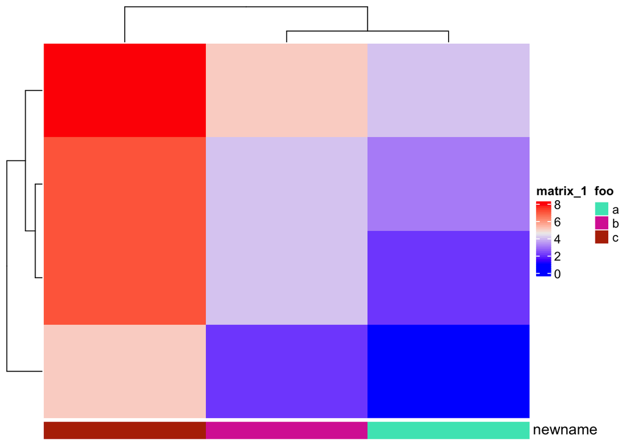

```r
library('gridtext')
test_df <- cbind(c(1,2,3,4), c(2,4,4,5), c(5,7,7,8))
Heatmap(
  test_df,
  bottom_annotation = HeatmapAnnotation(
    foo = c('a', 'b', 'c'),
    annotation_label  = gt_render('newname')
  )
)
```